# Decision Tree for Classification

Use bill_authentication.csv Preview the documentto predict whether a bank note is authentic or fake depending upon the four different attributes of the image of the note. The attributes are Variance of wavelet transformed image, curtosis of the image, entropy, and skewness of the image.

The rest of the steps to implement this algorithm in Scikit-Learn are identical to any typical machine learning problem, we will import libraries and datasets, perform some data analysis, divide the data into training and testing sets, train the algorithm, make predictions, and finally we will evaluate the algorithm's performance on our dataset

# Importing Libraries

```python
import pandas as pd
import numpy as np
import matplotlib.pyplot as plt
import seaborn as sns
import statsmodels.api as sm
```

# Importing the Dataset

Since our file is in CSV format, we will use panda's read_csv method to read our CSV data file

```python
data = pd.read_csv('bill_authentication.csv')
```

# Data Analysis

Execute the following command to inspect the first five records of the dataset

```python
data.head()
```

|  | Variance | Skewness | Curtosis | Entropy | Class |
| --- | --- | --- | --- | --- | --- |
| 0 | 3.62160 | 8.6661 | -2.8073 | -0.44699 | 0 |
| 1 | 4.54590 | 8.1674 | -2.4586 | -1.46210 | 0 |
| 2 | 3.86600 | -2.6383 | 1.9242 | 0.10645 | 0 |
| 3 | 3.45660 | 9.5228 | -4.0112 | -3.59440 | 0 |
| 4 | 0.32924 | -4.4552 | 4.5718 | -0.98880 | 0 |

Execute the following command to see the number of rows and columns in our dataset:

```python
print('Shape of the Dataset-->',data.shape)
```

```
Shape of the Dataset--> (1372, 5)
```

The output will show "(1372,5)", which means that our dataset has 1372 records and 5 attributes.

Printing the column indexes of the dataset

```python
print ('Columns names -->',data.columns)
```

```
Columns names --> Index(['Variance', 'Skewness', 'Curtosis', 'Entropy', 'Class'], dtype='object')
```

datatypes of the column features

```python
print ('Columns Datatype -->', data.dtypes)
```

```
Columns Datatype --> Variance    float64
Skewness    float64
Curtosis    float64
Entropy     float64
Class         int64
dtype: object
```

Checking weather there are any null values in that feature and there count

```python
data.isnull().sum()
```

```
Variance    0
Skewness    0
Curtosis    0
Entropy     0
Class       0
dtype: int64
```

Using visualization check the null values in the dataset

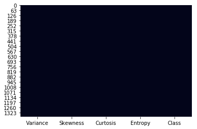

```python
sns.heatmap(data.isnull(), cbar=False)
```

Describing the entire datas mean,std,min,max of all the features in that data

```python
data.describe()
```

|  | Variance | Skewness | Curtosis | Entropy | Class |
| --- | --- | --- | --- | --- | --- |
| count | 1372.000000 | 1372.000000 | 1372.000000 | 1372.000000 | 1372.000000 |
| mean | 0.433735 | 1.922353 | 1.397627 | -1.191657 | 0.444606 |
| std | 2.842763 | 5.869047 | 4.310030 | 2.101013 | 0.497103 |
| min | -7.042100 | -13.773100 | -5.286100 | -8.548200 | 0.000000 |
| 25% | -1.773000 | -1.708200 | -1.574975 | -2.413450 | 0.000000 |
| 50% | 0.496180 | 2.319650 | 0.616630 | -0.586650 | 0.000000 |
| 75% | 2.821475 | 6.814625 | 3.179250 | 0.394810 | 1.000000 |
| max | 6.824800 | 12.951600 | 17.927400 | 2.449500 | 1.000000 |

Entire information of the data columns,type,memory usage.

```python
data.info()
```

```
<class 'pandas.core.frame.DataFrame'>
RangeIndex: 1372 entries, 0 to 1371
Data columns (total 5 columns):
Variance    1372 non-null float64
Skewness    1372 non-null float64
Curtosis    1372 non-null float64
Entropy     1372 non-null float64
Class       1372 non-null int64
dtypes: float64(4), int64(1)
memory usage: 53.7 KB
```

The correlation matrix of the dataset features

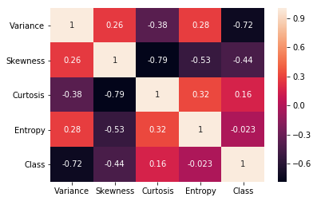

```python
correlation_matrix = data.corr()
sns.heatmap(data=correlation_matrix, annot=True)
```

Plotting Predictors Vs Target variable

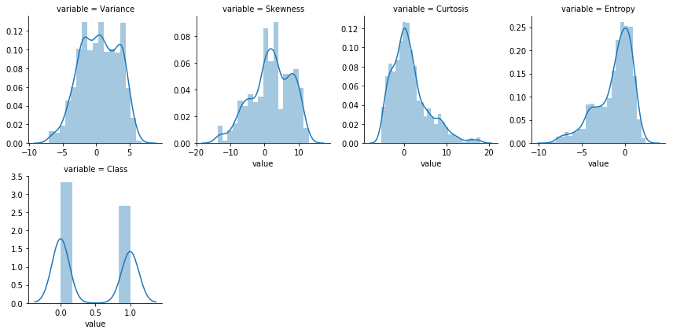

```python
num = [f for f in data.columns if data.dtypes[f] != 'object']
nd = pd.melt(data, value_vars = num)
n1 = sns.FacetGrid (nd, col='variable', col_wrap=4, sharex=False, sharey = False)
n1 = n1.map(sns.distplot, 'value')
n1
```

# Observations:

We Observe that we have less percent contribution from outliers in the data and we can ignore as the size of dataset is less

# Outliers Values

```python
#percentile of each Predictors
data.quantile([0.01,.05,.10,.15 ,.25,.5,.8,.85,0.9,.95,.99,1])
```

|  | Variance | Skewness | Curtosis | Entropy | Class |
| --- | --- | --- | --- | --- | --- |
| 0.01 | -6.223848 | -12.932698 | -4.922126 | -7.503400 | 0.0 |
| 0.05 | -4.145150 | -8.307735 | -4.093365 | -5.453985 | 0.0 |
| 0.10 | -3.309790 | -6.478490 | -3.439470 | -4.253770 | 0.0 |
| 0.15 | -2.573450 | -4.796175 | -2.941885 | -3.729060 | 0.0 |
| 0.25 | -1.773000 | -1.708200 | -1.574975 | -2.413450 | 0.0 |
| 0.50 | 0.496180 | 2.319650 | 0.616630 | -0.586650 | 0.0 |
| 0.80 | 3.421520 | 7.643080 | 4.563760 | 0.549980 | 1.0 |
| 0.85 | 3.802440 | 8.673905 | 5.830205 | 0.737219 | 1.0 |
| 0.90 | 4.117930 | 9.435490 | 7.881250 | 0.961180 | 1.0 |
| 0.95 | 4.714415 | 10.370835 | 9.806170 | 1.216225 | 1.0 |
| 0.99 | 5.693093 | 11.893197 | 15.575454 | 1.838823 | 1.0 |
| 1.00 | 6.824800 | 12.951600 | 17.927400 | 2.449500 | 1.0 |

# Visualizing Data with Pairs Plots

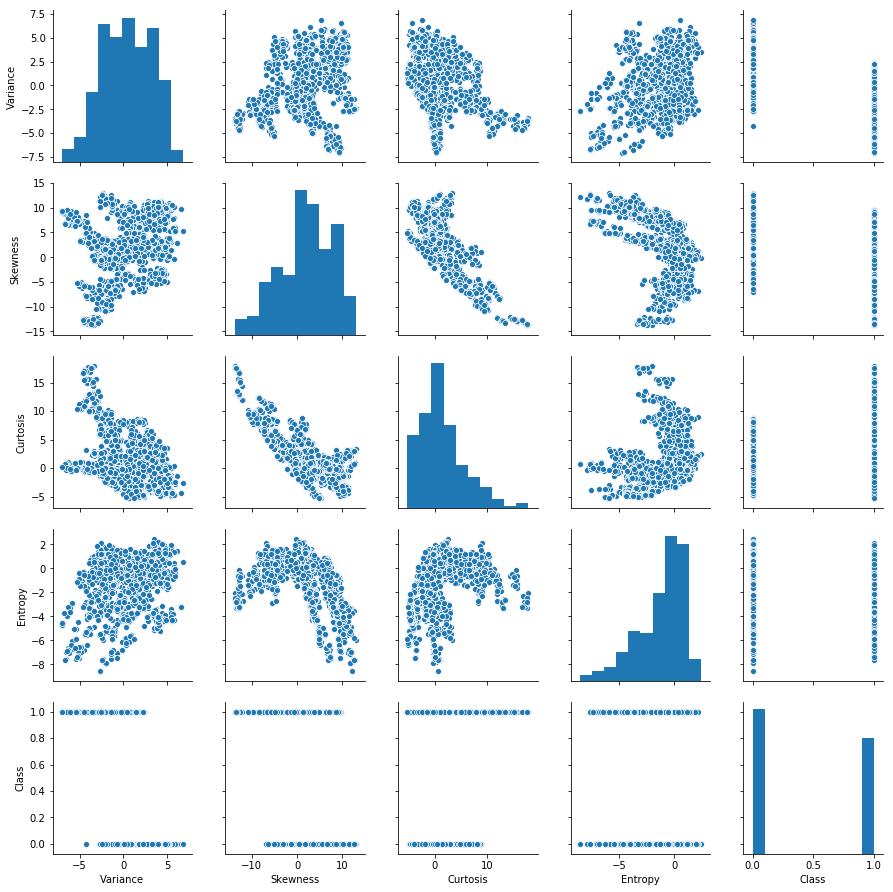

```python
sns.pairplot(data)
plt.show()
```

# Preparing the Data

As with the classification task, in this section we will divide our data into attributes and labels and consequently into training and test sets.

Execute the following commands to divide data into labels and attributes:

# Splitting the data into train (75%) and test(25%) of dependent and independent variables with random_state(seed) as 999

# Provided:

```
    #y: Single column dataframe holding our solution vector for logistic regression
    #x: A dataframe that runs parallel to y, with all the features for our logistic regression
```

```python
predictors=data.drop("Class", axis=1)
response=data['Class']
```

Here the predictors variable contains all the columns from the dataset, except 'class' column, which is the label. The response variable contains values from the 'class' column, which means that the predictors variable contains the attribute set and response variable contains the corresponding labels.

Execute the following code to divide our data into training and test sets:

```python
from sklearn.model_selection import train_test_split
X_train,X_test,Y_train,Y_test=train_test_split(predictors,response,test_size=0.25,random_state=999)
```

# Training and Making Predictions

```python
from sklearn.tree import DecisionTreeClassifier
tree_data = DecisionTreeClassifier(max_depth=4)
```

```python
tree_data.fit(X_train, Y_train)
```

```
DecisionTreeClassifier(class_weight=None, criterion='gini', max_depth=4,
            max_features=None, max_leaf_nodes=None,
            min_impurity_decrease=0.0, min_impurity_split=None,
            min_samples_leaf=1, min_samples_split=2,
            min_weight_fraction_leaf=0.0, presort=False, random_state=None,
            splitter='best')
```

To make predictions on the test set, ues the predict method:

```python
predictions = tree_data.predict(X_test)
```

```python
predictions[:5]
```

```
array([0, 0, 0, 1, 1], dtype=int64)
```

```python
Y_test[:5]
```

```
231     0
346     0
555     0
1195    1
1354    1
Name: Class, dtype: int64
```

Now let's compare some of our predicted values with the actual values and see how accurate we were

```python
df=pd.DataFrame({'Actual':Y_test, 'Predicted':predictions})
df
```

|  | Actual | Predicted |
| --- | --- | --- |
| 231 | 0 | 0 |
| 346 | 0 | 0 |
| 555 | 0 | 0 |
| 1195 | 1 | 1 |
| 1354 | 1 | 1 |
| 1219 | 1 | 1 |
| 248 | 0 | 0 |
| 165 | 0 | 0 |
| 132 | 0 | 0 |
| 1368 | 1 | 1 |
| 1164 | 1 | 1 |
| 843 | 1 | 1 |
| 131 | 0 | 0 |
| 851 | 1 | 1 |
| 548 | 0 | 0 |
| 767 | 1 | 1 |
| 989 | 1 | 1 |
| 1201 | 1 | 1 |
| 109 | 0 | 0 |
| 761 | 0 | 0 |
| 602 | 0 | 0 |
| 578 | 0 | 0 |
| 1169 | 1 | 1 |
| 1079 | 1 | 1 |
| 907 | 1 | 1 |
| 538 | 0 | 0 |
| 141 | 0 | 0 |
| 846 | 1 | 1 |
| 96 | 0 | 0 |
| 624 | 0 | 0 |
| ... | ... | ... |
| 939 | 1 | 1 |
| 905 | 1 | 1 |
| 683 | 0 | 0 |
| 958 | 1 | 1 |
| 449 | 0 | 0 |
| 1276 | 1 | 1 |
| 1017 | 1 | 1 |
| 376 | 0 | 0 |
| 353 | 0 | 0 |
| 1131 | 1 | 1 |
| 399 | 0 | 0 |
| 709 | 0 | 0 |
| 796 | 1 | 1 |
| 394 | 0 | 0 |
| 214 | 0 | 0 |
| 1108 | 1 | 1 |
| 1245 | 1 | 1 |
| 743 | 0 | 0 |
| 1282 | 1 | 1 |
| 175 | 0 | 0 |
| 765 | 1 | 1 |
| 1111 | 1 | 1 |
| 987 | 1 | 1 |
| 878 | 1 | 1 |
| 41 | 0 | 0 |
| 970 | 1 | 1 |
| 1168 | 1 | 1 |
| 495 | 0 | 0 |
| 633 | 0 | 0 |
| 192 | 0 | 0 |

343 rows × 2 columns

Remember that in your case the records compared may be different, depending upon the training and testing split. Since the train_test_split method randomly splits the data we likely won't have the same training and test sets.

# Calculate Accuracy

```python
from sklearn.metrics import accuracy_score, confusion_matrix
accuracy_score(Y_test, predictions)
```

```
0.9620991253644315
```

```python
r2_score(Y_test, predictions)
```

```
0.8478260869565217
```

```python
mean_absolute_error(Y_test, predictions_1)
```

[output not shown]

# Calculate number of correctly classified observations

```python
accuracy_score(Y_test, predictions, normalize=False)
```

```
330
```

# Calculate number of incorrectly classified observations.

```python
len(Y_test) - accuracy_score(Y_test, predictions, normalize=False)
```

```
13
```

# Calculate log loss

```python
from sklearn.metrics import log_loss
log_loss(Y_test, predictions)
```

```
1.3090614901486595
```

# Confusion matrix

```python
import pandas as pd
import matplotlib.pyplot as plt
import seaborn as sns
%matplotlib inline
```

```python
confusion_mat = confusion_matrix(Y_test, predictions)
```

```python
confusion_df = pd.DataFrame(confusion_mat, index=['Actual neg','Actual pos'], columns=['Predicted neg','Predicted pos'])
```

```python
confusion_df
```

|  | Predicted neg | Predicted pos |
| --- | --- | --- |
| Actual neg | 177 | 5 |
| Actual pos | 8 | 153 |

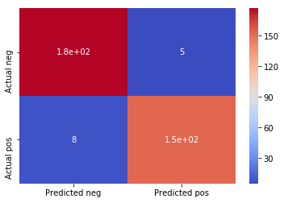

```python
_=sns.heatmap(confusion_df, cmap='coolwarm', annot=True)
```

# Calculate precision and recall scores¶

```python
from sklearn.metrics import precision_score, recall_score
precision_score(Y_test, predictions)
```

```
0.9683544303797469
```

```python
recall_score(Y_test, predictions)
```

```
0.9503105590062112
```

First,we import graphviz from sklearn for tree diagram, we export the tree output to a dot format object.

```python
from sklearn.tree import export_graphviz
import graphviz
```

```python
dot_data = export_graphviz(tree_data,filled=True, rounded=True,feature_names=['Variance','Skewness','Curtosis','Entropy'])
```

Next, we use graphviz to plot the dot data as a decision tree.

```python
graphviz.Source(dot_data)
```

[figure not shown]

# Summary

Tree based models split the data multiple times according to certain cutoff values in the features. Through splitting, different subsets of the dataset are created, with each instance belonging to one subset. The final subsets are called terminal or leaf nodes and the intermediate subsets are called internal nodes or split nodes. To predict the outcome in each leaf node, the average outcome of the training data in this node is used. Trees can be used for classification and regression.

precision score : 0.96

recall score : 0.95

log loss : 1.30

correct prediction : 330

incorrect prediction : 13

r2 score : 0.84

accuracy score : 0.96

From the above all the evaluation score values of the classifiction decision tree with depth 4 we got the readings as above.

the accuracy score for model with test sample we got 0.96 which is a best model for predictions as we compare with the no of samples we have very less amount of data rows we need to check with multiple random seed .

we have correctly predicted 330 among 343 and 13 are incorrect values amoong 343 .

by considering log loss we have very minor log loss 1.30 and precision and recall scores as 96% and 95%.

# Tree interpretation

we have 5 features among them 4 are labels('Variance','Skewness','Curtosis','Entropy') and 1 is target variable(Class).

Classification tree the root of the tree is selected with the gini value calculated with neighbour features and which ever is having max information gain is considered as root.

Feature variance <=0.312 and gini value 0.49 and no of samples of records 1029 and values between 580 and 449

**condition variance is less then or equal to 0.312 it will send to the left side True to the Skewness as decision box with <= 7.56 is again two childs(decison branch) variance with <=-0.404 , gini value 0.136 and variance with <=-4.72 ,gini value =0.28 ,no of samples 83 into 2 leafs gini = 0 left sample have 14 rows and value[0,14] and right leaf sample rows have value[69,0].

**Variance in second branch variance <=-0.403 is divided into 2 subsclasses with Curtosis <=6.74 and Curtosis <=0.441 with samples 348 and 61 , gini values 0.072 and 0.402 .Two curtosis each have 2 leafs left curtosis left branch have gini 0.008 and 0.213 with samples 249 and 99.Right Decision branch Curtosis with gini 0.097 and 0.43 with samples 39 and 22.

**From root branch with false decision Curtosis <=-4.443 with gini 0.187 with samples 537 is divided into 2 more decison branches right variance <=1.59 and left variance <=3.205 and left Variance having gini value 0.336 of samples 29 is divided into leafs with gini values 0 and left leaf have 22 samples with value [0,22] and right leaf value [7,0]

**From the right variance <=1.59 with gini 0.125 of samples 508 have 2 more decison branches left Curtosis and right Variance ,left Curtosis have gini value 0.359 with samples 141 divided into 2 leafs ,left leaf gini = 0.255 and samples 20 and value [3,17] and right decision branch Variance <=2.018 with gini 0.005 and no of samples 367 is divided into 2 leafs left and right ,left leaf with gini =.049 and sample 40 and value=[39,1] and right leaf with gini 0.0and samples 327 and values [327,0]

```python
import numpy as np
```

```python
np.unique(predictions)
```

```
array([0, 1], dtype=int64)
```

Unique predictions of the target 0 and 1

We can also export the graph to other formats like png, pdf etc. by using pydotplus package.

```python
from pydotplus import graph_from_dot_data
graph = graph_from_dot_data(dot_data)
```

```python
graph.write_png("classification_tree.png")
```

```
True
```

# Classification using Decision Tree with GridSearch and Cross-Validation

Import Decision Tree Classification, and GridSearchCV and fit the model to the training data.

```python
from sklearn.tree import DecisionTreeClassifier
from sklearn.model_selection import GridSearchCV
```

```python
param_grid = [{"max_depth":[3,4,5,6,7,8, None], "max_features":[1,2,3,4]}]
```

```python
gs = GridSearchCV(estimator=DecisionTreeClassifier(random_state=6),\
                 param_grid = param_grid,\
                 cv=10)
```

Fit the training data

```python
gs.fit(X_train, Y_train)
```

```
GridSearchCV(cv=10, error_score='raise-deprecating',
       estimator=DecisionTreeClassifier(class_weight=None, criterion='gini', max_depth=None,
            max_features=None, max_leaf_nodes=None,
            min_impurity_decrease=0.0, min_impurity_split=None,
            min_samples_leaf=1, min_samples_split=2,
            min_weight_fraction_leaf=0.0, presort=False, random_state=6,
            splitter='best'),
       fit_params=None, iid='warn', n_jobs=None,
       param_grid=[{'max_depth': [3, 4, 5, 6, 7, 8, None], 'max_features': [1, 2, 3, 4]}],
       pre_dispatch='2*n_jobs', refit=True, return_train_score='warn',
       scoring=None, verbose=0)
```

Print out all the hyperparameters combinations that the GridSearchCV has tried.

```python
gs.cv_results_['params']
```

```
[{'max_depth': 3, 'max_features': 1},
 {'max_depth': 3, 'max_features': 2},
 {'max_depth': 3, 'max_features': 3},
 {'max_depth': 3, 'max_features': 4},
 {'max_depth': 4, 'max_features': 1},
 {'max_depth': 4, 'max_features': 2},
 {'max_depth': 4, 'max_features': 3},
 {'max_depth': 4, 'max_features': 4},
 {'max_depth': 5, 'max_features': 1},
 {'max_depth': 5, 'max_features': 2},
 {'max_depth': 5, 'max_features': 3},
 {'max_depth': 5, 'max_features': 4},
 {'max_depth': 6, 'max_features': 1},
 {'max_depth': 6, 'max_features': 2},
 {'max_depth': 6, 'max_features': 3},
 {'max_depth': 6, 'max_features': 4},
 {'max_depth': 7, 'max_features': 1},
 {'max_depth': 7, 'max_features': 2},
 {'max_depth': 7, 'max_features': 3},
 {'max_depth': 7, 'max_features': 4},
 {'max_depth': 8, 'max_features': 1},
 {'max_depth': 8, 'max_features': 2},
 {'max_depth': 8, 'max_features': 3},
 {'max_depth': 8, 'max_features': 4},
 {'max_depth': None, 'max_features': 1},
 {'max_depth': None, 'max_features': 2},
 {'max_depth': None, 'max_features': 3},
 {'max_depth': None, 'max_features': 4}]
```

Print best hyperparameters combination

```python
gs.best_params_
```

```
{'max_depth': 6, 'max_features': 3}
```

```python
gs.cv_results_['rank_test_score']
```

```
array([28, 25, 20, 23, 27, 22, 14, 18, 26, 24, 10, 12, 21, 15,  1, 10, 19,
       13,  1,  7, 16,  5,  1,  7, 17,  5,  1,  7])
```

Print the complete DecisionTree estimator.

```python
gs.best_estimator_
```

```
DecisionTreeClassifier(class_weight=None, criterion='gini', max_depth=6,
            max_features=3, max_leaf_nodes=None, min_impurity_decrease=0.0,
            min_impurity_split=None, min_samples_leaf=1,
            min_samples_split=2, min_weight_fraction_leaf=0.0,
            presort=False, random_state=6, splitter='best')
```

Make predictions for the test set.

```python
predictions_1 = gs.predict(X_test)
```

Now let's compare some of our predicted values with the actual values and see how accurate

```python
df_1=pd.DataFrame({'Actual':Y_test, 'Predicted':predictions_1})
df_1
```

|  | Actual | Predicted |
| --- | --- | --- |
| 231 | 0 | 0 |
| 346 | 0 | 0 |
| 555 | 0 | 0 |
| 1195 | 1 | 1 |
| 1354 | 1 | 1 |
| 1219 | 1 | 1 |
| 248 | 0 | 0 |
| 165 | 0 | 0 |
| 132 | 0 | 0 |
| 1368 | 1 | 1 |
| 1164 | 1 | 1 |
| 843 | 1 | 1 |
| 131 | 0 | 0 |
| 851 | 1 | 1 |
| 548 | 0 | 0 |
| 767 | 1 | 1 |
| 989 | 1 | 1 |
| 1201 | 1 | 1 |
| 109 | 0 | 0 |
| 761 | 0 | 0 |
| 602 | 0 | 0 |
| 578 | 0 | 0 |
| 1169 | 1 | 1 |
| 1079 | 1 | 1 |
| 907 | 1 | 1 |
| 538 | 0 | 0 |
| 141 | 0 | 0 |
| 846 | 1 | 1 |
| 96 | 0 | 0 |
| 624 | 0 | 0 |
| ... | ... | ... |
| 939 | 1 | 1 |
| 905 | 1 | 1 |
| 683 | 0 | 0 |
| 958 | 1 | 1 |
| 449 | 0 | 0 |
| 1276 | 1 | 1 |
| 1017 | 1 | 1 |
| 376 | 0 | 0 |
| 353 | 0 | 0 |
| 1131 | 1 | 1 |
| 399 | 0 | 0 |
| 709 | 0 | 0 |
| 796 | 1 | 1 |
| 394 | 0 | 0 |
| 214 | 0 | 0 |
| 1108 | 1 | 1 |
| 1245 | 1 | 1 |
| 743 | 0 | 0 |
| 1282 | 1 | 1 |
| 175 | 0 | 0 |
| 765 | 1 | 1 |
| 1111 | 1 | 1 |
| 987 | 1 | 1 |
| 878 | 1 | 1 |
| 41 | 0 | 0 |
| 970 | 1 | 1 |
| 1168 | 1 | 1 |
| 495 | 0 | 0 |
| 633 | 0 | 0 |
| 192 | 0 | 0 |

343 rows × 2 columns

# Calculate accuracy of prediction

```python
from sklearn.metrics import mean_absolute_error, r2_score,accuracy_score
mean_absolute_error(Y_test, predictions_1)
```

```
0.023323615160349854
```

```python
accuracy_score(Y_test, predictions_1)
```

```
0.9766763848396501
```

```python
r2_score(Y_test, predictions_1)
```

```
0.9063545150501672
```

# Calculate number of correctly classified observations

```python
accuracy_score(Y_test, predictions_1, normalize=False)
```

```
335
```

# Calculate number of incorrectly classified observations.

```python
len(Y_test) - accuracy_score(Y_test, predictions_1, normalize=False)
```

```
8
```

# Calculate log loss

```python
from sklearn.metrics import log_loss
log_loss(Y_test, predictions_1)
```

```
0.805580784683489
```

# Confusion matrix

```python
# import matplotlib and seaborn for visualization and metrix
from sklearn.metrics import confusion_matrix
import matplotlib.pyplot as plt
import seaborn as sns
%matplotlib inline
```

```python
confusion_mat = confusion_matrix(Y_test, predictions_1)
```

```python
confusion_df = pd.DataFrame(confusion_mat, index=['Actual neg','Actual pos'], columns=['Predicted neg','Predicted pos'])
```

```python
confusion_df
```

|  | Predicted neg | Predicted pos |
| --- | --- | --- |
| Actual neg | 177 | 5 |
| Actual pos | 3 | 158 |

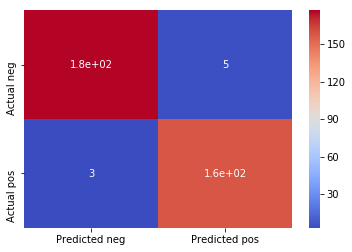

```python
_=sns.heatmap(confusion_df, cmap='coolwarm', annot=True)
```

# Calculate precision and recall scores¶

```python
from sklearn.metrics import precision_score, recall_score
precision_score(Y_test, predictions_1)
```

```
0.9693251533742331
```

```python
recall_score(Y_test, predictions_1)
```

```
0.9813664596273292
```

# F1 Score

```python
from sklearn.metrics import f1_score
f1_score(Y_test, predictions_1)
```

```
0.9753086419753085
```

F1 score is also a key factor verifying the model condition to check weather that model is good or not.here,0.98 is a says that this model is very good.

```python
from sklearn.metrics import roc_curve, roc_auc_score
probs = gs.predict_proba(X_test)[::,1]
auc = roc_auc_score(Y_test, probs)
print(auc)
```

```
0.9769469660774007
```

```python
fpr, tpr, threshold = roc_curve(Y_test, probs)
```

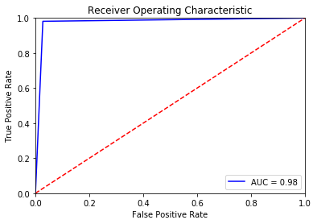

```python
plt.title('Receiver Operating Characteristic')
plt.plot(fpr, tpr, 'b', label = 'AUC = %0.2f' % auc)
plt.legend(loc = 'lower right')
plt.plot([0, 1], [0, 1],'r--')
plt.xlim([0, 1])
plt.ylim([0, 1])
plt.ylabel('True Positive Rate')
plt.xlabel('False Positive Rate')
plt.show()
```

# We can also calculate the optimal threshold probability from this ROC curve.

```python
optimal_idx = np.argmax(tpr - fpr)
optimal_threshold = threshold[optimal_idx]
```

```python
optimal_threshold
```

```
1.0
```

First,we import graphviz from sklearn for tree diagram, we export the tree output to a dot format object.

```python
from sklearn.tree import export_graphviz
```

```python
dot_data_1 = export_graphviz(gs.best_estimator_,filled=True, rounded=True,feature_names=['Variance','Skewness','Curtosis','Entropy'])
```

Next, we use graphviz to plot the dot data as a decision tree.

```python
import graphviz
```

```python
graphviz.Source(dot_data_1)
```

[figure not shown]

# Summary

Tree based models split the data multiple times according to certain cutoff values in the features. Through splitting, different subsets of the dataset are created, with each instance belonging to one subset. The final subsets are called terminal or leaf nodes and the intermediate subsets are called internal nodes or split nodes. To predict the outcome in each leaf node, the average outcome of the training data in this node is used. Trees can be used for classification and regression.

precision score : 0.96

recall score : 0.98

log loss : 0.80

correct prediction : 335

incorrect prediction : 8

r2 score : 0.90

mean absolute error : 0.02

accuracy score : 0.97

From the above all the evaluation score values of the classifiction decision tree with depth 6 and features 3 we got the readings as above.

the accuracy score for model with test sample we got 0.97 which is a best model for predictions as we compare with the no of samples we have very less amount of data rows we need to check with multiple random seed .

we have correctly predicted 335 among 343 and 8 are incorrect values amoong 343 .

by considering log loss we have very minor log loss 0.80 and precision and recall scores as 96% and 98%.

# Tree interpretation

we have total 5 features among them 4 are labels('Variance','Skewness','Curtosis','Entropy') and 1 is target variable(Class).

now in this decision tree with depth 6 and features 3 ,explaining the tree diagram

Classification tree the root of the tree is selected with the gini value calculated with neighbour features and which ever is having max information gain is considered as root.

Feature variance <=5.161 and gini value 0.49 and no of samples of records 1029 and values between 580 and 449 which is divided into 2 decison branches left variance <=0.84 and right Entropy <=-5.89.

**From the above condition,left decision branch Variance with gini 0.479 ,samples 690 ,values[274,416] which divides into 2 decistion tree with Variance <= 0.312 and Curtosis <= -1.718 with Curtosis gini 0.177,sample 255,value [230,25] have one decison branch Variance <= 3.318 and leaf node with gini 0.0 ,sample 228,value [228,0] and Variance <= 3.318 have 2 leats left and right have gini 0 and samples 25,2 and value[0,25],[2,0]

**Decision branch of top 2nd left branch Variance <=0.312,gini 0.812,samples 435,value [44,39] have two child decision branch Curtosis <=6.746,gini 0.099,samples 381,value [20,361] and Curtosis <=0.47,gini 0.494,samples 54,value [24,30] having one leaf branch on left gini 0,sample 29,value [0,29] and decision branch Skewness <= -3.363 with one leaf on right gini 0.0,sample 20,value [20,0] and one decision branch Entropy <=0.056,gini 0.32,sample 5,value [4,1] having 2 leafs left and right gini 0.0,samples 4,1,values [4,0] , [0,1].

**The decison branch Curtosis <=6.746,gini 0.099,samples 381,value [20,361] with 2 decison branches Curtosis <=4.846,gini 0.007,samples 275,value [1,274] and Variance <= -1.395,gini 0.294,sample 106,value [19,87] having single decison branch Variance <=-1.395,gini 0.294,samples 106,values [19,87] having 2 branch decision nodes Skewness <= -2.461 and Skewness <= -6.294 gini 0.104,0.124 samples 91,15 having 2 leaf nodes each left decison Skewnwss gini 0.0,samples 86,5 ,values [0,86],[5,0] and right decison Skewness node left and right leaf gini 0.0 ,samples 1,14 .

**The decison branch Curtosis <=4.846,gini 0.007,samples 275,value [1,274] have one leaf on left gini 0,samples 241 and decision branch Curtosis <=4.94,gini 0.057,samples 34,value [1,33] having 2 leaf nodes left and right with gini 0.0,samples 1,33,values [1,0],[0,33].

**Right decison branch of the root node Entropy <=-5.89,gini 0.176,sample 339,value [301,33] dividing into single branches Variance <= -.3.304,gini 0.48,sample 35 into one leaf gini 0,sample 20,value [0,20] and decison branch Variance<=0.443,gini 0.124,sample 14,value [14,1] into 2 leafs right anf left gini 0,sample 1 ,14.

**Right decison branch of the branch node Entropy <=-4.478,gini 0.076,sample 304,value [292,12] divided into 2 decison branches Skweness and Variance <= -5.084, gini 0.03,samples 265 ,values [261,4] into 2 leaf nodes right and left wth gini 0,samples 4,261 and Decision branch Skewness <=9.057,gini 0.326,sample 39 into 2 decision branches Curtosis <=1.397 and Entropy <= -4.729 ,gini 0.062,samples 31 ,value [30,1] into 2 leaf nodes with gini 0.0,samples 30,1 and Left Decison branch Curtosis <=1.397 ,gini 0.219,sample 8,value [1,7] into 2 leaf nodes left and right with gini 0.0,samples 7,1 and values [7,0],[0,1].

```python
import numpy as np
```

```python
np.unique(predictions_1)
```

```
array([0, 1], dtype=int64)
```

We can also export the graph to other formats like png, pdf etc. by using pydotplus package.

```python
from pydotplus import graph_from_dot_data
```

```python
graph_1 = graph_from_dot_data(dot_data_1)
```

```python
graph_1.write_png("classification_tree_1.png")
```

```
True
```

# Conclusion:

The Model decision trees with hyperparamter and default depth and feature models

**Default depth of 4 with all features

precision score : 0.96

recall score : 0.95

log loss : 1.30

correct prediction : 330

incorrect prediction : 13

r2 score : 0.84

accuracy score : 0.96

**Using hyperparameter best suitable depth and features

precision score : 0.96

recall score : 0.98

log loss : 0.80

correct prediction : 335

incorrect prediction : 8

r2 score : 0.90

mean absolute error : 0.02

accuracy score : 0.97

Roc Curve Auc = 97.6%

Treshold = 1.0

**We got a good accuracy score using the and less log loss and predicted more correctly using the test data.

**Note :F1 score : 0.97 this mean the model is best fit using this depth and features with 97 percent confident

**Finally using Grid Search to find the optimal value for the hyperparameters, and evaluate your model on the appropriate metrics gives more accurate and confidence for the new data predictions.